# INLA, BYM and BYM2 in Pictures

- Show All Code
- Hide All Code
- View Source

Same counties, three ways to read a map

Author

Eric M. Delmelle · Lehigh University

## Today

Last time we smoothed the Pennsylvania lung cancer map. Today we open the box: what INLA does, and what is inside the BYM and BYM2 models. Mostly pictures. Reading: **Moraga §5.2–5.3**.

| Model | log-risk of county $i$ | In words |
| --- | --- | --- |
| Raw SIR | — | each county on its own |
| BYM | $\beta_0 + u_i + v_i$ | overall level + a neighbours map + a noise map |
| BYM2 | $\beta_0 +$ mix of $u_i$ and $v_i$ | the same two maps, mixed with one knob, $\phi$ |

```r
library(sf)
library(dplyr)
library(tidyr)
library(ggplot2)
library(patchwork)
library(spdep)
library(SpatialEpi)   # pennLC
library(INLA)
```

**Data and map helpers (same data as last lecture)**

```r
data(pennLC)
d <- pennLC$data

ref <- d |>
  group_by(race, gender, age) |>
  summarise(r = sum(cases) / sum(population), .groups = "drop")   # reference rates

county <- d |>
  left_join(ref, by = c("race", "gender", "age")) |>
  group_by(county) |>
  summarise(O = sum(cases), E = sum(population * r), .groups = "drop") |>
  mutate(county = as.character(county), SIR = O / E)

pa <- st_as_sf(pennLC$spatial.polygon) |>
  st_set_crs(4326) |>
  mutate(county = names(pennLC$spatial.polygon)) |>
  st_transform(5070) |>                                           # Albers
  left_join(county, by = "county")

risk_breaks <- c(0, 0.67, 0.83, 0.95, 1.05, 1.2, 1.5, Inf)
risk_labels <- c("< 0.67", "0.67-0.83", "0.83-0.95", "0.95-1.05",
                 "1.05-1.2", "1.2-1.5", "> 1.5")

map_risk <- function(values, title = NULL) {                     # relative risk, fixed classes
  ggplot(pa) +
    geom_sf(aes(fill = cut(values, risk_breaks, risk_labels)),
            colour = "white", linewidth = 0.15) +
    scale_fill_brewer(palette = "RdBu", direction = -1, drop = FALSE,
                      name = "Relative\nrisk") +
    labs(title = title) +
    theme_void(base_size = 11)
}

map_effect <- function(values, title = NULL, lim = max(abs(values))) {   # log scale, centred on 0
  ggplot(pa) +
    geom_sf(aes(fill = values), colour = "white", linewidth = 0.15) +
    scale_fill_distiller(palette = "RdBu", limits = c(-lim, lim),
                         oob = scales::squish, name = "Effect\n(log scale)") +
    labs(title = title) +
    theme_void(base_size = 11)
}

tc <- function(x) tools::toTitleCase(x)                          # county names
f2 <- function(x) sprintf("%.2f", x)                             # two decimals
```

# 1 The problem in one picture

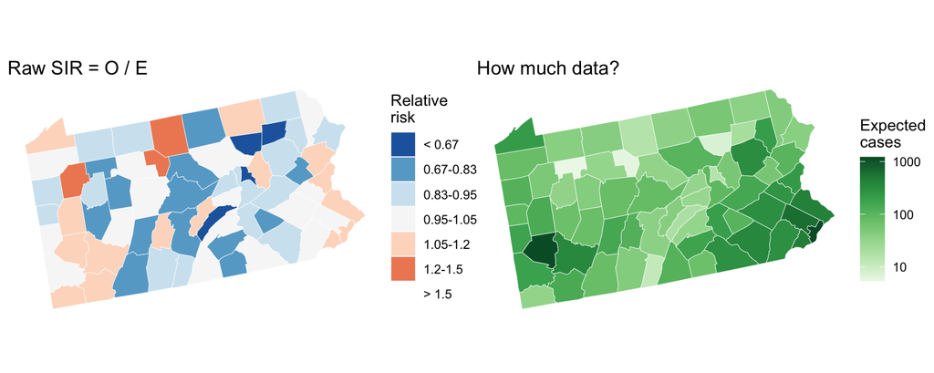

Figure 1: Left: raw SIRs. Right: how much data each county has.

```r
p_data <- ggplot(pa) +
  geom_sf(aes(fill = E), colour = "white", linewidth = 0.15) +
  scale_fill_distiller(palette = "Greens", direction = 1, trans = "log10",
                       name = "Expected\ncases") +
  labs(title = "How much data?") +
  theme_void(base_size = 11)

map_risk(pa$SIR, "Raw SIR = O / E") + p_data
```

The darkest reds and blues on the left tend to sit in the palest counties on the right: little data, noisy SIR. Every model today is a way to **borrow** information so these counties calm down.

# 2 INLA in two pictures

## 2.1 What we want: a curve, not a number

A Bayesian model returns, for each county, a whole **posterior curve**: which relative risks are plausible, and how plausible. There are two ways to get it.

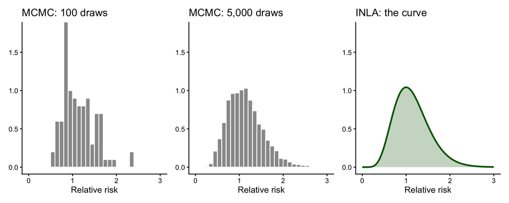

Figure 2: Same posterior, two routes. MCMC draws random values and builds a histogram; INLA computes the curve.

```r
a <- 8; b <- 7                                     # an illustrative posterior
set.seed(374)

hist_panel <- function(n) {
  ggplot(tibble(x = rgamma(n, a, b)), aes(x)) +
    geom_histogram(aes(y = after_stat(density)), binwidth = 0.1, boundary = 0,
                   fill = "grey60", colour = "white") +
    coord_cartesian(xlim = c(0, 3), ylim = c(0, 1.8)) +
    labs(title = paste0("MCMC: ", format(n, big.mark = ","), " draws"),
         x = "Relative risk", y = NULL) +
    theme_classic(base_size = 11)
}

p_inla <- ggplot(tibble(x = seq(0, 3, 0.01)), aes(x, dgamma(x, a, b))) +
  geom_area(fill = "darkgreen", alpha = 0.25) +
  geom_line(colour = "darkgreen", linewidth = 1) +
  coord_cartesian(xlim = c(0, 3), ylim = c(0, 1.8)) +
  labs(title = "INLA: the curve", x = "Relative risk", y = NULL) +
  theme_classic(base_size = 11)

hist_panel(100) + hist_panel(5000) + p_inla
```

**MCMC** is like a poll: draw thousands of plausible values and count them. It works for almost any model, but it is slow, and you must check that it drew enough. **INLA** skips the drawing and computes the curve with an approximation. For disease maps it takes seconds, and its curves are usually very close to MCMC’s (Rue et al. 2009).

## 2.2 The trick: a bell curve at the top

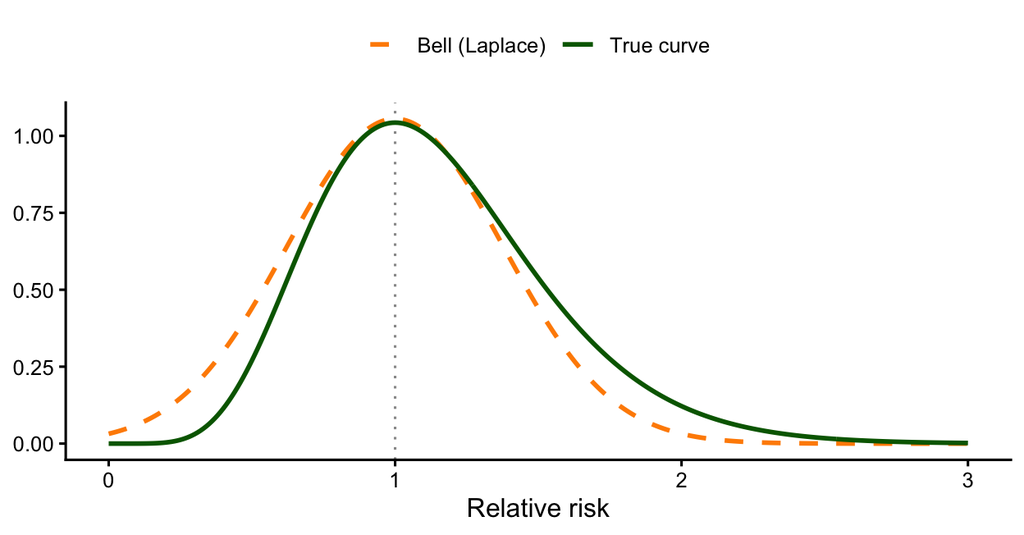

Figure 3: The Laplace approximation: a bell curve with the same peak and the same width at the top.

```r
peak  <- (a - 1) / b                               # top of the curve
width <- sqrt(a - 1) / b                           # width at the top

tibble(x = seq(0, 3, 0.01),
       `True curve`     = dgamma(x, a, b),
       `Bell (Laplace)` = dnorm(x, peak, width)) |>
  pivot_longer(-x, names_to = "curve", values_to = "density") |>
  ggplot(aes(x, density, colour = curve, linetype = curve)) +
  geom_vline(xintercept = peak, colour = "grey60", linetype = 3) +
  geom_line(linewidth = 1) +
  scale_colour_manual(values = c("True curve" = "darkgreen", "Bell (Laplace)" = "darkorange")) +
  scale_linetype_manual(values = c("True curve" = 1, "Bell (Laplace)" = 2)) +
  labs(x = "Relative risk", y = NULL, colour = NULL, linetype = NULL) +
  theme_classic(base_size = 12) +
  theme(legend.position = "top")
```

Close, not exact. INLA works on the log scale, where curves are closer to a bell, and then corrects the bell. The name says the rest:

| Letters | Stands for | In plain words |
| --- | --- | --- |
| I | Integrated | averages over the few unknown settings of the model, e.g. how smooth the map is |
| N | Nested | approximations inside approximations: first those settings, then each county |
| LA | Laplace Approximation | a bell curve fitted at the top of each curve, then refined |

**TipKey idea**

You never see any of this. You write a formula; INLA returns one curve per county. Today only the `model = ...` part of the formula changes.

```r
inla(O ~ 1 + f(id, model = "...", graph = g),     # overall level + county effects
     family = "poisson", E = E,                   # counts against expected cases
     data = dat)
```

# 3 Who are my neighbours?

```r
nb <- poly2nb(pa, queen = TRUE)                    # queen neighbours
nb2INLA("pa.adj", nb)                              # write for INLA
g  <- inla.read.graph("pa.adj")

dat <- st_drop_geometry(pa) |>
  mutate(id = row_number())                        # one index per county
```

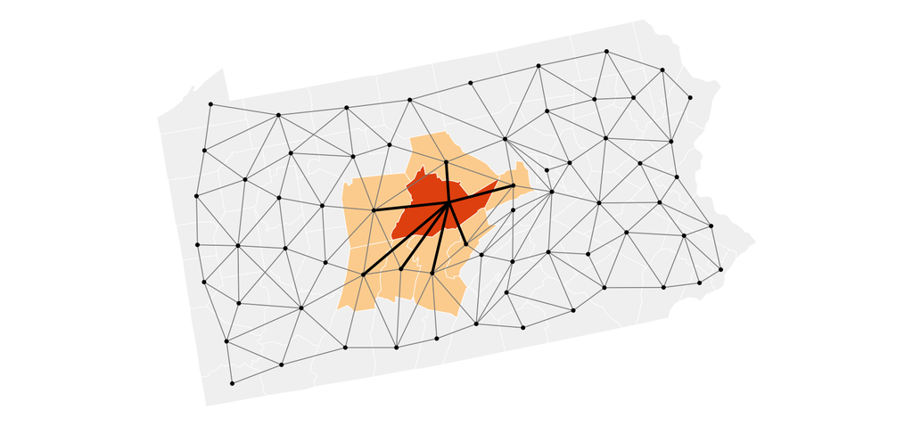

Figure 4: Each line joins two neighbours. Orange: Centre County. Light orange: its neighbours.

```r
ic <- which(pa$county == "centre")                 # Centre County
xy <- unname(st_coordinates(st_point_on_surface(st_geometry(pa))))   # one point per county

links <- do.call(rbind, lapply(seq_along(nb), function(i) {
  j <- nb[[i]][nb[[i]] > i]                        # each pair once
  if (length(j) == 0) return(NULL)
  data.frame(x = xy[i, 1], y = xy[i, 2], xend = xy[j, 1], yend = xy[j, 2],
             centre = i == ic | j == ic)
}))

ggplot() +
  geom_sf(data = pa, fill = "grey95", colour = "white") +
  geom_sf(data = pa[nb[[ic]], ], fill = "#FDD49E", colour = "white") +   # neighbours
  geom_sf(data = pa[ic, ], fill = "#E6550D", colour = "white") +         # Centre
  geom_segment(data = links,
               aes(x, y, xend = xend, yend = yend, colour = centre, linewidth = centre)) +
  geom_point(data = data.frame(X = xy[, 1], Y = xy[, 2]), aes(X, Y), size = 0.8) +
  scale_colour_manual(values = c(`FALSE` = "grey55", `TRUE` = "black"), guide = "none") +
  scale_linewidth_manual(values = c(`FALSE` = 0.3, `TRUE` = 0.9), guide = "none") +
  theme_void()
```

Centre County has 7 neighbours. In BYM and BYM2, a county borrows from the counties it is linked to, not from the whole state.

# 4 BYM: two hidden maps

## 4.1 Neighbours map and noise map

BYM (Besag, York and Mollié 1991) says the log-risk of county $i$ is an overall level plus two hidden maps:

$$\log \theta_i \;=\; \beta_0 \;+\; \underbrace{u_i}_{\text{neighbours}} \;+\; \underbrace{v_i}_{\text{noise}}$$

What do these two maps look like before we see any data? Here is one random draw of each.

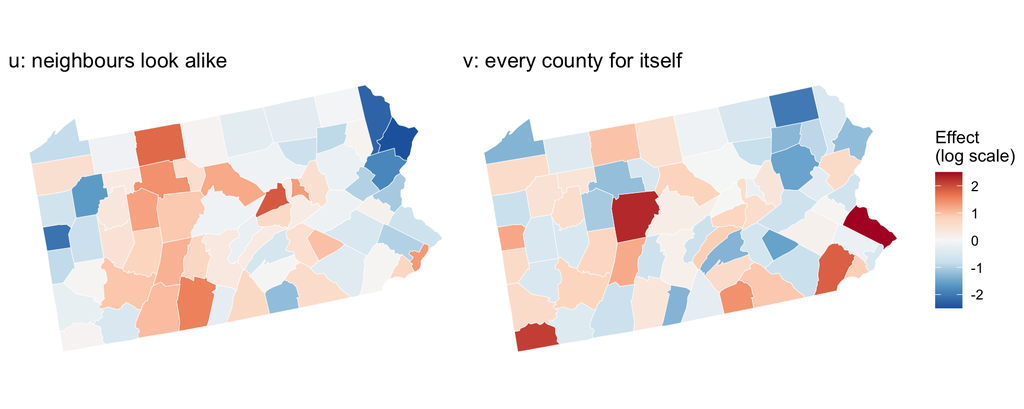

Figure 5: Left: u, a smooth map where neighbours look alike (structured). Right: v, pure county-to-county noise (unstructured). Simulated.

```r
W <- nb2mat(nb, style = "B")                       # 1 = neighbours
Q <- diag(rowSums(W)) - 0.99 * W                   # nearly the ICAR (Besag) prior
set.seed(374)
u_sim <- as.vector(scale(backsolve(chol(Q), rnorm(nrow(pa)))))   # smooth map
v_sim <- as.vector(scale(rnorm(nrow(pa))))                       # pure noise

map_effect(u_sim, "u: neighbours look alike", lim = 2.5) +
  map_effect(v_sim, "v: every county for itself", lim = 2.5) +
  plot_layout(guides = "collect")
```

A real map is a mix of both. BYM lets the data decide how much of each.

## 4.2 Fitting BYM

```r
dat$idu <- dat$id                                  # one index per f() term
dat$idv <- dat$id

m_bym <- inla(O ~ 1 + f(idu, model = "besag", graph = g) +   # u: neighbours
                      f(idv, model = "iid"),                 # v: noise
              family = "poisson", E = E, data = dat,
              control.predictor = list(compute = TRUE),
              control.compute = list(dic = TRUE, waic = TRUE))

b0         <- m_bym$summary.fixed["(Intercept)", "mean"]   # overall level
dat$u      <- m_bym$summary.random$idu$mean                # neighbours map
dat$v      <- m_bym$summary.random$idv$mean                # noise map
dat$RR_bym <- m_bym$summary.fitted.values$mean             # relative risk
```

Writing BYM as two `f()` terms shows its two pieces. INLA also offers it in one piece, `model = "bym"`.

## 4.3 The BYM map as an addition

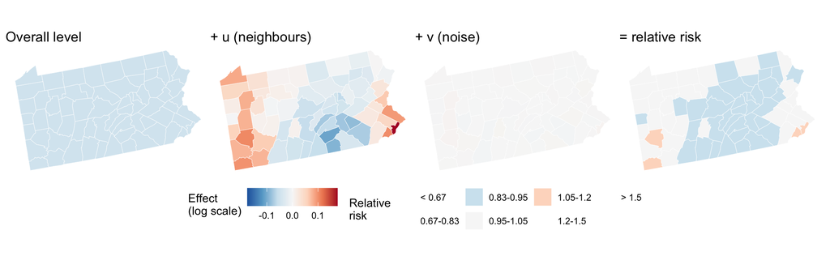

Figure 6: Pennsylvania’s BYM map, piece by piece. The first three maps share one colour scale.

```r
lim <- max(abs(c(b0, dat$u, dat$v)))               # one scale for the pieces

map_effect(rep(b0, nrow(pa)), "Overall level", lim) +
  map_effect(dat$u, "+ u (neighbours)", lim) +
  map_effect(dat$v, "+ v (noise)", lim) +
  map_risk(exp(b0 + dat$u + dat$v), "= relative risk") +
  plot_layout(nrow = 1, guides = "collect") &
  theme(legend.position = "bottom")
```

Read it left to right. The overall level is the same everywhere. Then each county gets a bump from its neighbourhood ($u$) and a bump of its own ($v$). Because the three pieces share one scale, the stronger colours show which hidden map carries more of Pennsylvania’s pattern.

**WarningThe catch with BYM**

BYM has two knobs: how much $u$ varies and how much $v$ varies. They are hard to read, and they compete: the data cannot easily tell which map should carry a pattern, so the two knobs are hard to estimate and to set priors for (Riebler et al. 2016). BYM2 replaces them with two knobs that mean something.

# 5 BYM2: one knob, φ

## 5.1 Turning the knob

BYM2 keeps the same two hidden maps and mixes them:

$$\log \theta_i \;=\; \beta_0 \;+\; \frac{1}{\sqrt{\tau}}
\Big(\sqrt{\phi}\;u_i^{*} \;+\; \sqrt{1-\phi}\;v_i\Big)$$

$u^*$ is $u$ rescaled to the same typical size as $v$. Then $\tau$ says **how much** counties differ, and $\phi$, between 0 and 1, says **how spatial** the differences are. Here is the knob, on the two simulated maps from above:

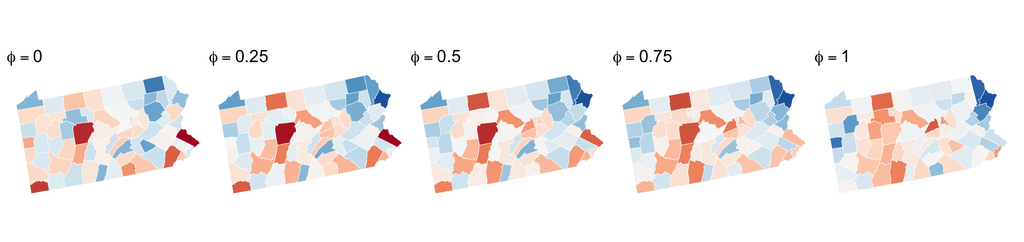

Figure 7: Mixing the same two maps with φ. Left: all noise. Right: all neighbours. Every panel has the same total variation.

```r
phis <- c(0, 0.25, 0.5, 0.75, 1)

knob <- lapply(phis, function(p) {
  map_effect(sqrt(p) * u_sim + sqrt(1 - p) * v_sim,   # BYM2 mix
             bquote(phi == .(p)), lim = 2.5) +
    theme(legend.position = "none")
})

wrap_plots(knob, nrow = 1)
```

Only the **shape** of the map changes with $\phi$, not how much it varies. That is why $\phi$ is easy to read: the share of the variation that is spatial.

## 5.2 Fitting BYM2

```r
m_bym2 <- inla(O ~ 1 + f(id, model = "bym2", graph = g),    # both maps in one term
               family = "poisson", E = E, data = dat,
               control.predictor = list(compute = TRUE),
               control.compute = list(dic = TRUE, waic = TRUE,
                                      return.marginals.predictor = TRUE))

dat$RR_bym2 <- m_bym2$summary.fitted.values$mean            # relative risk
round(m_bym2$summary.hyperpar[, 1:5], 2)                    # τ and φ
```

|  | mean | sd | 0.025quant | 0.5quant | 0.975quant |
| --- | --- | --- | --- | --- | --- |
| Precision for id | 132.25 | 55.39 | 56.06 | 121.76 | 269.96 |
| Phi for id | 0.53 | 0.23 | 0.10 | 0.54 | 0.93 |

We use INLA’s default priors; Moraga §5.3 shows how to set your own.

## 5.3 Where does Pennsylvania sit on the knob?

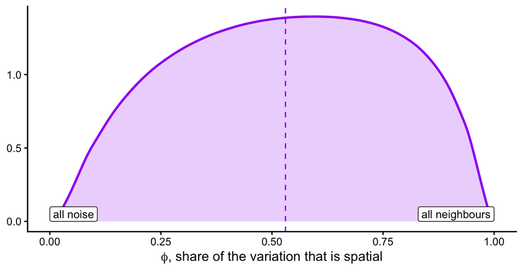

Figure 8: Posterior curve of φ for lung cancer in Pennsylvania. Dashed: posterior mean.

```r
phi_curve <- inla.smarginal(m_bym2$marginals.hyperpar$`Phi for id`)   # INLA's curve
phi_mean  <- m_bym2$summary.hyperpar["Phi for id", "mean"]
phi_ci    <- unlist(m_bym2$summary.hyperpar["Phi for id", c("0.025quant", "0.975quant")])

ggplot(as.data.frame(phi_curve), aes(x, y)) +
  geom_area(fill = "purple", alpha = 0.2) +
  geom_line(colour = "purple", linewidth = 1) +
  geom_vline(xintercept = phi_mean, colour = "purple", linetype = 2) +
  annotate("label", x = c(0, 1), y = 0, label = c("all noise", "all neighbours"),
           hjust = c(0, 1), vjust = 0, size = 3.5) +
  coord_cartesian(xlim = c(0, 1)) +
  labs(x = expression(paste(phi, ", share of the variation that is spatial")), y = NULL) +
  theme_classic(base_size = 12)
```

The posterior mean of $\phi$ is 0.53, with 95% probability between 0.10 and 0.93. In the knob figure, Pennsylvania sits closest to the panel $\phi$ = 0.5. BYM could only hint at this by comparing colours; BYM2 gives it as one number, with its uncertainty.

# 6 Three maps, side by side

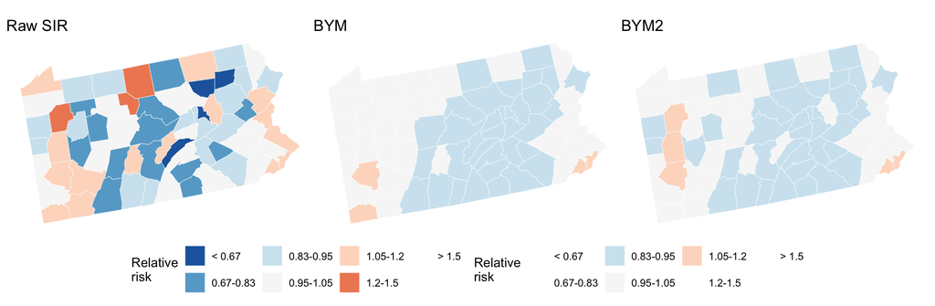

Figure 9: Raw SIR, BYM and BYM2. Same colours.

```r
map_risk(dat$SIR, "Raw SIR") +
  map_risk(dat$RR_bym, "BYM") +
  map_risk(dat$RR_bym2, "BYM2") +
  plot_layout(nrow = 1, guides = "collect") &
  theme(legend.position = "bottom")
```

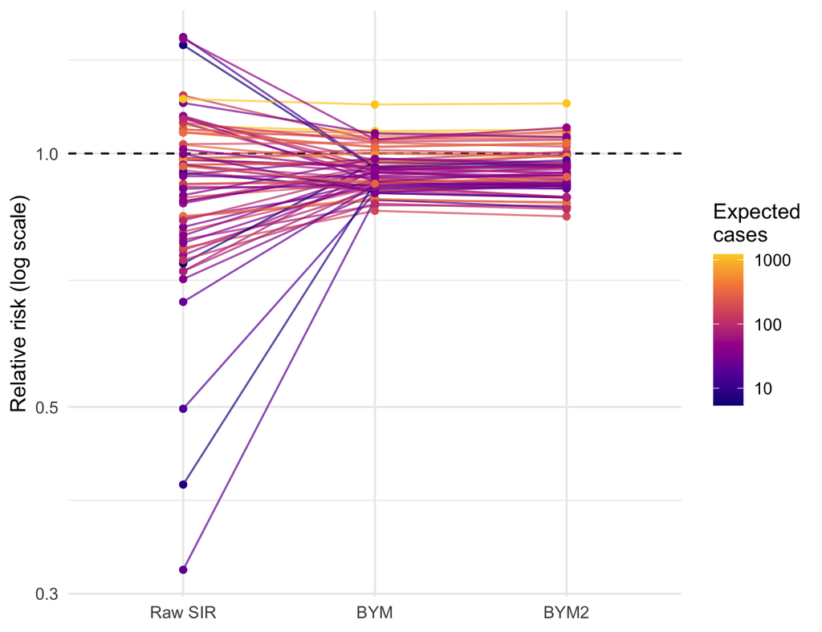

Figure 10: Where each county goes. Each line is one county; dark lines are small counties.

```r
dat |>
  select(county, E, `Raw SIR` = SIR, BYM = RR_bym, BYM2 = RR_bym2) |>
  pivot_longer(c(`Raw SIR`, BYM, BYM2), names_to = "estimate", values_to = "risk") |>
  mutate(estimate = factor(estimate, c("Raw SIR", "BYM", "BYM2"))) |>
  ggplot(aes(estimate, risk, group = county, colour = E)) +
  geom_hline(yintercept = 1, linetype = 2) +
  geom_line(alpha = 0.7) +
  geom_point(size = 1.5) +
  scale_colour_viridis_c(option = "plasma", end = 0.9, trans = "log10",
                         name = "Expected\ncases") +
  scale_y_log10() +
  labs(x = NULL, y = "Relative risk (log scale)") +
  theme_minimal(base_size = 12)
```

Small counties start far from 1 and are pulled in; big counties barely move. BYM and BYM2 nearly agree: the largest difference for any county is 0.04.

```r
tibble(model = c("BYM", "BYM2"),
       DIC   = c(m_bym$dic$dic,   m_bym2$dic$dic),
       WAIC  = c(m_bym$waic$waic, m_bym2$waic$waic)) |>
  mutate(across(c(DIC, WAIC), \(x) round(x, 1)))       # lower is better
```

| model | DIC | WAIC |
| --- | --- | --- |
| BYM | 515.3 | 516.6 |
| BYM2 | 514.2 | 512.8 |

Lower is better, but a difference of a few points means little. We prefer BYM2 not for a better map but because its knobs mean something.

# 7 What we report

```r
dat$p_exc <- sapply(m_bym2$marginals.fitted.values,
                    \(m) 1 - inla.pmarginal(1, m))   # P(risk > 1)
```

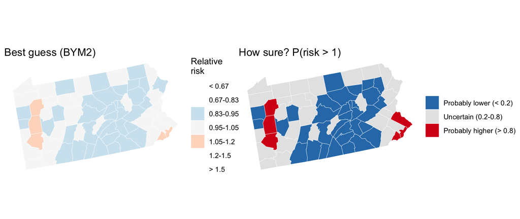

Figure 11: Left: best guess (BYM2). Right: probability that the risk is above the state average.

```r
exc_cols <- c("Probably lower (< 0.2)"  = "#2c7bb6",
              "Uncertain (0.2-0.8)"     = "grey90",
              "Probably higher (> 0.8)" = "#d7191c")
exc <- cut(dat$p_exc, c(0, 0.2, 0.8, 1), labels = names(exc_cols),
           include.lowest = TRUE)

p_exc <- ggplot(pa) +
  geom_sf(aes(fill = exc), colour = "white", linewidth = 0.15) +
  scale_fill_manual(values = exc_cols, drop = FALSE, name = NULL) +
  labs(title = "How sure? P(risk > 1)") +
  theme_void(base_size = 11)

map_risk(dat$RR_bym2, "Best guess (BYM2)") + p_exc
```

A good disease map comes in pairs: the best guess, and how sure we are about it.

# Check yourself

1. In the BYM addition figure, which hidden map, $u$ or $v$, has the stronger colours? What does that say about $\phi$?
2. In the slope chart, find the line that moves the most. Is it a small or a big county? Why?
3. If $\phi$ were 0, what would BYM2 become? Which method from last lecture does it resemble?

# Cheat sheet

```r
nb <- poly2nb(pa)                                          # 1. neighbours
nb2INLA("pa.adj", nb); g <- inla.read.graph("pa.adj")
dat$id <- 1:nrow(dat)                                      # 2. one index per county

m <- inla(O ~ 1 + f(id, model = "bym2", graph = g),        # 3. model
          family = "poisson", E = E, data = dat,
          control.predictor = list(compute = TRUE))

dat$RR <- m$summary.fitted.values$mean                     # 4. relative risk
m$summary.hyperpar                                         # 5. τ and φ
```

# Words to know

| Word | Plain meaning |
| --- | --- |
| INLA | a fast way to compute posterior curves, without drawing samples |
| Laplace approximation | a bell curve fitted at the top of a curve |
| $u$, structured effect | hidden map where neighbours look alike (ICAR, or Besag, prior) |
| $v$, unstructured effect | hidden map of county-to-county noise |
| BYM | overall level + $u$ + $v$ |
| BYM2 | the same two maps, mixed by $\phi$ |
| $\phi$ | share of the variation between counties that is spatial |
| $\tau$ | precision: how little counties differ overall (large $\tau$, small differences) |

# References

Besag, J., York, J., & Mollié, A. (1991). Bayesian image restoration, with two applications in spatial statistics. *Annals of the Institute of Statistical Mathematics*, 43(1), 1–20.

Moraga, P. (2019). *Geospatial health data: Modeling and visualization with R-INLA and Shiny*. Chapman & Hall/CRC, Ch. 5.

Riebler, A., Sørbye, S. H., Simpson, D., & Rue, H. (2016). An intuitive Bayesian spatial model for disease mapping that accounts for scaling. *Statistical Methods in Medical Research*, 25(4), 1145–1165.

Rue, H., Martino, S., & Chopin, N. (2009). Approximate Bayesian inference for latent Gaussian models by using integrated nested Laplace approximations. *Journal of the Royal Statistical Society: Series B*, 71(2), 319–392.